# Experimental probability with python

## Estimating the outcomes of coin toss trials:

In the case of a coin toss, we have two possible outcomes viz., a Head or a Tail. For the sake of programming let's associate numbers 0 and 1 to the Head and the Tail respectively. That is Head ---> 0 and Tail --> 1.

Now, if we can somehow make the computer to display either 0 or 1 and no other number each time we ask it to produce a number, we will be technically mimicking a coin toss experiment. Such communications between us and the computer are generally made through the use of what are known as programming languages, and the instructions directing the computer to respond in the particular way we desire are called programs.

In this lesson we use a programming language named Python. The program given below simulates a cointoss experiment of N trials out of which we want to know how many times the Tail (number 1) showed up.

```python
import random   # importing a library named "random" that gives out random numbers but because we specially need just the integers 0 and 1 as outputs,we'll have to reference a subset of the library, as will be done later

N=1000
#print('Number of times to repeat the trial = ', N)

i=0 # counter initialization. Needed as a reference to start counting the number of times a particular outcome pops up in the repeated trials

for x in range(N):            # Conveys that the steps following this line are repeated N times...(that is the trial will be repeated N times)
    #print(x)
    a=random.randint(0,1)     #Generates integer random numbers either 0 or 1 each time it is called (here we call it N times)
    #print(a)
    if a==1:                  #Each time a==1, we increment the count of i by 1. That is, we make a count for each Tail
        i=i+1
        #print(i)

print('Number of occurances = ', i, 'out of',N,', implies, the probability = ', i/N)
```

```
Number of occurances =  506 out of 1000 , implies, the probability =  0.506
```

Excercises: (1) Run the code changing N (2) Re-run the code for a fixed N

```
        What did you observe?
```

Concept check (C1): In a given run, if you observe the number of occurances of Tails to be more than (or less than) 50 percent of the number of trials performed (N), what do you think would have resulted in the hypothetical 'N+1' th trial and why? (Hint/solution?: Has to do whith the way the numbers are generated.)

Programming Excercise: If two coins are tossed, what is the probability that both of them show Tails. (Solution below)

In order to carry out this experiment, you may probably ask two volunteers to step forward, give them a coin each and ask them to toss the coins a number of times (say N trials) and count the times (say Nt) both the tosses show up Tails. The probability can then be calculated as Nt over N.

Going by the previous demonstration, we can represent the two coins as a,b = random.randint(0,1), run it in a loop N times and count the instances when both a and b are '1'.

```python
import random   # importing a library named "random" that gives out random numbers but because we specially need just the integers 0 and 1 as outputs,we'll have to reference a subset of the library, as will be done later

N=100000
#print('Number of times to repeat the trial = ', N)

i=0 # counter initialization. Needed as a reference to start counting the number of times a particular outcome pops up in the repeated trials

for x in range(N):            # Conveys that the steps following this line are repeated N times...(that is the trial will be repeated N times)
    a=random.randint(0,1)     #outcome of the first coin
    b=random.randint(0,1)     #outcome of the second coin
    if a==1 and b==1:          #Count only when we have a Tail on both the coins
        i=i+1
        #print(i)

print('Number of occurances = ', i, 'out of',N,', implies, the probability = ', i/N)
```

```
Number of occurances =  24966 out of 100000 , implies, the probability =  0.24966
```

Excerise: What is the probability that either or both the coins turn up Tails?

```python
import random   # importing a library named "random" that gives out random numbers but because we specially need just the integers 0 and 1 as outputs,we'll have to reference a subset of the library, as will be done later

N=1000
#print('Number of times to repeat the trial = ', N)

i=0 # counter initialization. Needed as a reference to start counting the number of times a particular outcome pops up in the repeated trials

for x in range(N):            # Conveys that the steps following this line are repeated N times...(that is the trial will be repeated N times)
    a=random.randint(0,1)     #outcome of the first coin
    b=random.randint(0,1)     #outcome of the second coin
    if (a==1 and b==0) or (a==0 and b==1) or (a==1 and b==1):          #Count when we have a Tail from either or both the coins
        i=i+1
        #print(i)

print('Number of occurances = ', i, 'out of',N,', implies, the probability = ', i/N)
```

```
Number of occurances =  756 out of 1000 , implies, the probability =  0.756
```

Exercise: We could have simply written the conditional (if) statement in the above program as "if(a==1 or b==1): i = i+1", i.e., count when either a or b shows a Tail without giving any special consideration to the case when both the coin showup Tails. Can you say why?

The probability of two successive trials showing up Tails:

Now this is a conceptually tricky problem for the following reason. Because the outcome of successive tosses are independent of eachother (hint for C1), at first glace, it appears that the problem may be treated as equivalent to the second experiment (i.e., two coins both showing up Tails in a toss). As a matter of fact, the theoretical probability that a coin shows up two Tails(or heads) in succession (i.e., on both the first and the second try), given as Probability(Tail in the first toss) multiplied by Probability(Tail in the second toss) = 0.5*0.5 = 0.25, is evidently very close to the estimated probability obtained in that case. (Concept check C2: Is it a mere coincidence? Justify your answer.) [Hint/Solution?: In the above reasoning, the number of tosses made would be 2N (as 'a' and 'b' both refer to the same coin).]

A different approach would be to just count the number of times (say Ns) the Tail turns up in two successions, in the N total trials performed. But in such a case, the start and stop trails are arbitrary/ambiguous. (Technically, we cannot proceed with the trials if the first toss is a Head, or stop when the last (N th) toss is a Tail.). Given the nature of probability (that we talk about estimates for a large N), this (ambiguity) should not be a problem however, and one can simply 'tie-up' the first and the last trial 'bins' to form a cycle, so that the outcome of the N+1 th trial is taken the same as that of the first. The estimated probability can then be obtained as = Ns/N.

```python
from numpy import random  # need to import random from numpy to use the size argument

N=1000
#print('Number of times to repeat the trial = ', N)
x = random.choice([0,1], size=(N)) #generate a 1D array of N elements containing either 0 or 1 (outcomes from N trials)
#print(x)
i=0
if(x[0]==1 and x[N-1]==1):        #assuming the first and last trial bins are cyclic, we check if both showup Tails
    i=i+1
for k in range(N-1):
    #print(x[k],x[k+1])
    if(x[k]==1 and x[k+1]==1):        ## the usual, checking if the 'k'th and 'k+1'th trial outcomes are both Tails
        i=i+1


print('Number of occurances = ', i, 'out of',N,', implies, the probability = ', i/(N))
```

```
Number of occurances =  259 out of 1000 , implies, the probability =  0.259
```

The appropriate method to perform the experiment is to divide the volunteers into N groups of N numbers each (i.e., the total number of volunteers are NxN). Ask them to toss a coin, and advance only those that flipped a Tail (expected to be ~0.5N) to perform the second toss (expected to be half of the previous numbers, i.e., the 'conjugate' probability ~ 0.5*0.5N = 0.25N). This can be programmed as given under.

```python
import random   # importing a library named "random" that gives out random numbers but because we specially need just the integers 0 and 1 as outputs,we'll have to reference a subset of the library, as will be done later

N=100
#print('Number of times to repeat the trial = ', N)

i=0 # counter initialization. Needed as a reference to start counting the number of times a particular outcome pops up in the repeated trials

for x in range(N):            # Conveys that the steps following this line are repeated N times...(that is the trial will be repeated N times)
    a=random.randint(0,1)     #outcome of the first trial
    for y in range(N):        #for each first trail
        b=random.randint(0,1)     #outcome of the second trial
        if a==1 and b==1:          #Count only when both the tosses show up Tails
            i=i+1
        #print(i)

print('Number of occurances = ', i, 'out of',N*N,', implies, the probability = ', i/(N*N))
```

```
Number of occurances =  2258 out of 10000 , implies, the probability =  0.2258
```

Infer from the results obtained with different N, which among the above two methods is more efficient (and robust)?

## Estimating the outcome from a dice roll:

Programming Excercise: Can you alter the first coin-toss code to simulate dice play trials (solution below)

```python
import random   # importing a library named "random" that gives out random numbers but because we specially need just the integers 0 and 1 as outputs,we'll have to reference a subset of the library, as will be done later

N=1000
#print('Number of times to repeat the trial = ', N)

i=0 # counter initialization. Needed as a reference to start counting the number of times a particular outcome pops up in the repeated trials

for x in range(N):            # Conveys that the steps following this line are repeated N times...(that is the trial will be repeated N times)
    #print(x)
    a=random.randint(1,6)     #Generates integer random numbers between 1 to 6 (6 numbers) each time it is called (here we call it N times)
    #print(a)
    if a==1:                  #Each time a==1, we increment the count of i by 1. That is, we make a count for showup of number 1 on the dice
        i=i+1
        #print(i)

print('Number of occurances = ', i, 'out of',N)
print('The probability in this case = ', i/N)
```

```
Number of occurances =  159 out of 1000
The probability in this case =  0.159
```

Did you spot the difference between the two programs? Repeat the excercises as performed in the above case.

## Method to obtain an approximate value of Pi - The random dart throw experiment:

This is a fun idea. Imagine a square of side 1 unit, at the centre of which we draw a circle of radius "r" units, where 2r <= 1. (That is, the biggest circle that can be drawn is the one that touches the sides of the square). Now, if I were to throw a dart, which can randomly hit any location within the square (talk about being a terrible player!), the chance of a hit within the circle is given by the ratio of their areas. That is, the area of the circle of radius r over the area of the square of side 1, = pi*r^2.

In order to be able to do an experiment, we have to make altleast two assumptions.

(1) The indentations of the dart are smaller than the size of the circle. (2) The boundary between the interior and the exterior of the circle is ultra thin (well defined but much smaller than the dart so that the latter can either fall inside or the outside of the circle, but NOT on the boundary)!.That is, we can either count a hit to be either inside or the outside of the circle.

To programme the same on a computer, we simple have to assign numbers say "0" and "1" for hits outside and inside respectively. That is, Hit outside --> 0 and Hit inside --> 1. Now, any point of the square, and of course the circle, can take a value either 0 or 1. But the problem is, by definition a point is infinitesimal in size and we therefore have infinite number of points (mathematicians call it a continous field of the coordinates) making up the circle/square. As each of these points can have either of the two values..that makes it a double infinity! (To the infinity and beyond...oh wait, should't it still be treated as infinity?).

Anyways, although computers may handle large numbers with some difficulty, they still have to be finite in value and in quantity (I mean, how many times did you get a "NaN" or an "Error" on a calculator/computer when multiplying two or more big numbers). We therefore picture the square to be made of tightly packed smaller bins (placed next to eachother). Each of the bins may or maynot be occupied, in which case we assign values 1 or 0 respectively. A better analogy is a TV screen which contains a number of pixels along both, the horizonatal and vertical directions. For our particular case, each of these pixels can either take a value of 1 (white lit) or 0 (not lit or black)....no grey shades please!. In such a case, the dart throw is analogous to lighting up a randomly selected pixel. And the original problem translates to asking for the probability of lighting up a pixel (selected randomly), to be located inside a circle drawn on the screen. This should be equal to the ratio of number of pixels inside the circle to the total pixels (making up the screen). (Convince yourself that, as long as the pixels are uniformly distributed, this ratio of the numbers should be the same as the ratio of areas as calculated before?).

Now, all we have to do is randomly light up the pixels in repeated trials and count everytime it is inside the circle. Well that's what we do in the following program.

```python
import random   # importing a library named "random" that gives out random numbers

N=100
r = 0.5
#print('Number of times to repeat the trial = ', N x N) # As we have both horizontal and vertical pixel lineup

i=0 # Let the counting begin!

for a in range(N):
    for b in range(N):
        x=random.uniform(-r,r)
        y=random.uniform(-r,r)
        if x**2 + y**2 <= r**2:
            i=i+1

Probability = i/(N*N)
print('Probability of falling within the circle = ', Probability)
```

```
Probability of falling within the circle =  0.785
```

Now because this should also be close to pi*r^2, equating the two leads us to a formula for estimating the value of pi (the only 'unknown' in the equation) as pi = Probability/r^2

```python
pi = Probability/(r*r)
print('Therefore the approximate value of pi obtained using this method = ', pi)
```

```
Therefore the approximate value of pi obtained using this method =  3.14
```

Did you see how close we are to the exact value of pi?.

There are difficulties with this method, in particular, the boundaries of the circle are not be treated as perfect (circular) rims but as jagged steps only approximating it. Also, should or shouldn't we count the number of pixels making up this boundary? Such questions arise, but as long as we deal with large number of pixels, we expect the total error to be small. (Can you justify this in more concrete terms?)

Excercise: Try increasing the N and/or change r and analyse the results.

Now for a little commercial!

## Ad.: Do you know that there was once an attempt to pass a bill to define pi = 3.

## Did you ever felt that the true value of pi is not what you are always being told?

## Do you have that burning desire to find it yourself and attain nirvana.

## Try Pi-seeker2.0...now with graphing capability and added commentary.

(Disclaimer: Accuracy tested under lab. conditions (code executed just once). Deviations are expected depending on user's enthusiasm and the machine's mood. We take no responsibility if your pizza comes out smaller than the size you want to make.)

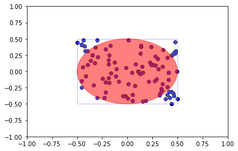

```
Estimated probability of a dart hit within the circle =  75 out of 100 --> 0.75
Therefore the approximate value of pi obtained using this method =  3.0
```

```python
import random   # importing a library named "random" that gives out random numbers
%matplotlib inline

import matplotlib.pyplot as plt #importing python plotting library as plt



N=10    #number of pixels/bins along horizontal/vertical directions..total number of pixels = N x N
R = 0.5  #radius of the circle
#print('Number of times to repeat the trial = ', N x N) # As we have both horizontal and vertical pixel lineup

fig, ax = plt.subplots()
circle=plt.Circle((0,0),r,alpha=0.5,color='r')  #plotting the reference circle of radius 'R'
rectangle = plt.Rectangle((-0.5,-0.5), 1, 1, fc='white',alpha = 0.25, ec="blue") ## plotting the square 'TV screen'
plt.gca().add_patch(rectangle)

ax.add_artist(circle)

ax.axis([-1, 1,-1, 1])

i=0 # Let the counting begin!


for a in range(N):
    for b in range(N):
        x=random.uniform(-R,R)
        y=random.uniform(-R,R)
        if x**2 + y**2 <= R**2:
            i=i+1                  # count only those that fall inside the circle of radius 'R'
        ax.scatter(x, y, color='blue', edgecolors='black')


plt.show()


Pro = i/(N*N)
print('Estimated probability of a dart hit within the circle = ', i ,'out of', N*N, '-->', Pro)
Pi = Pro/(R*R)
print('Therefore the approximate value of pi obtained using this method = ', Pi)
```